# Project 3 - Wine Analysis

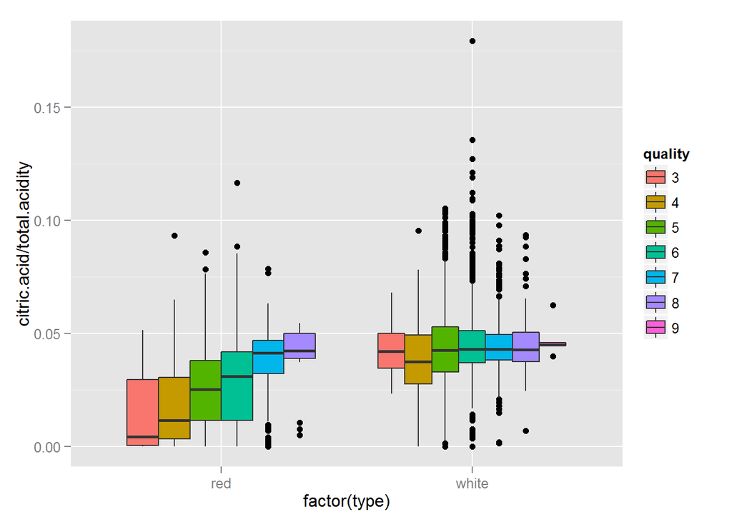

```r
ggplot(wine,aes(factor(type),citric.acid/total.acidity,fill=quality))+
  geom_boxplot()
```

These ratios seem to highlight some of the differences in the quality a little bit better than raw values. I am interested in seeing these relationships with the pH values as well. pH is a log scale based on concentration.

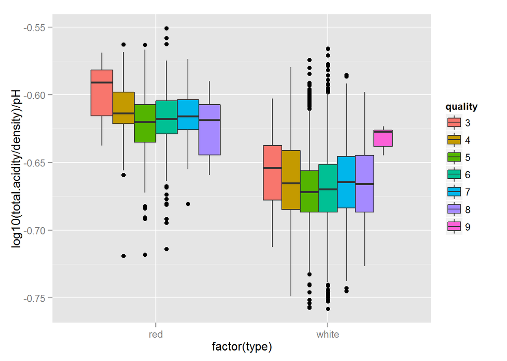

```r
ggplot(wine,aes(factor(type),log10(total.acidity/density)/pH,fill=quality))+
  geom_boxplot()
```

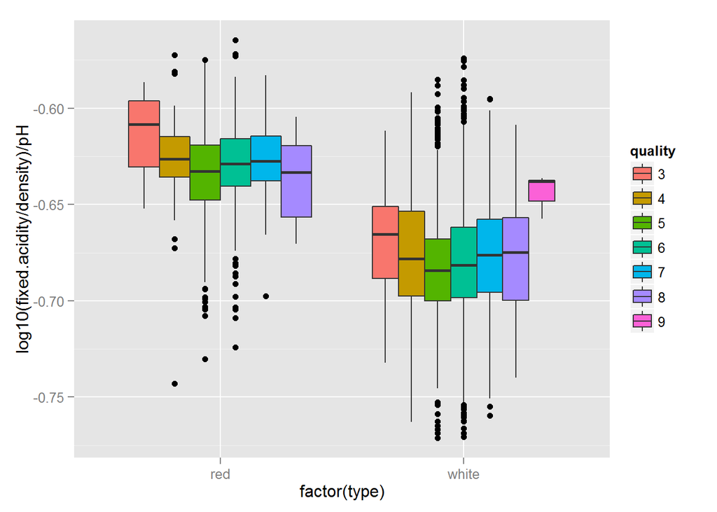

```r
ggplot(wine,aes(factor(type),log10(fixed.acidity/density)/pH,fill=quality))+
  geom_boxplot()
```

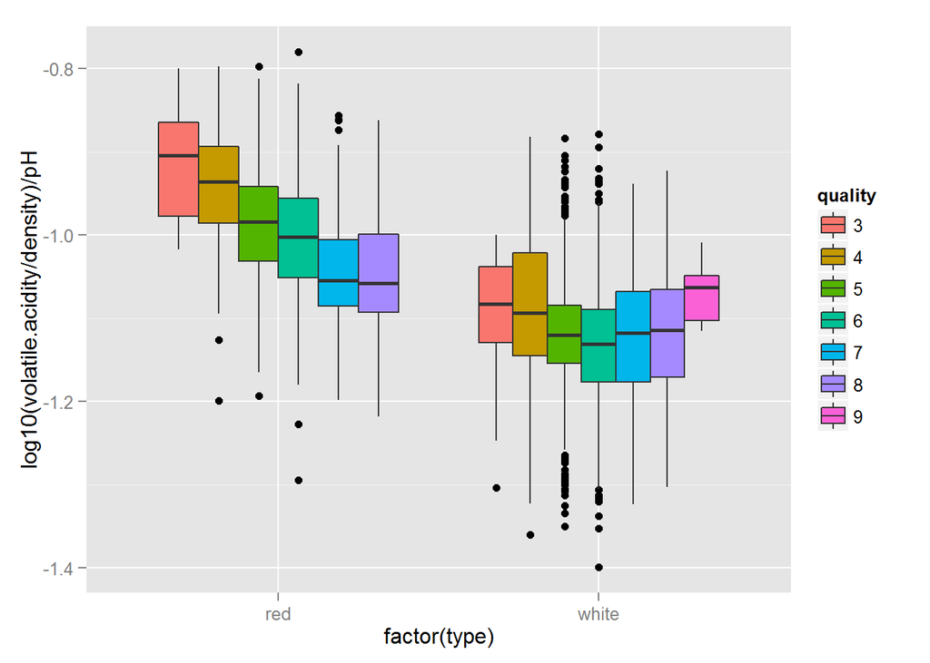

```r
ggplot(wine,aes(factor(type),log10(volatile.acidity/density)/pH,fill=quality))+
  geom_boxplot()
```

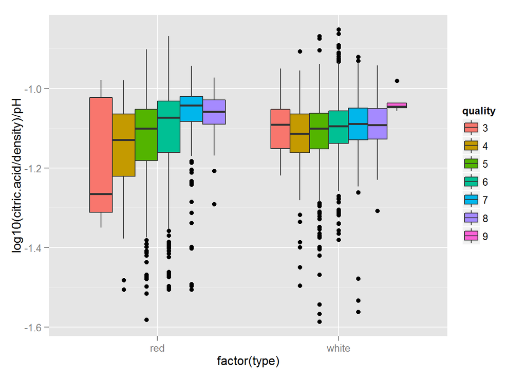

```r
ggplot(wine,aes(factor(type),log10(citric.acid/density)/pH,fill=quality))+
  geom_boxplot()
```

These plots do not illustrate anything new but before I move on I want to look at some 2D plots.

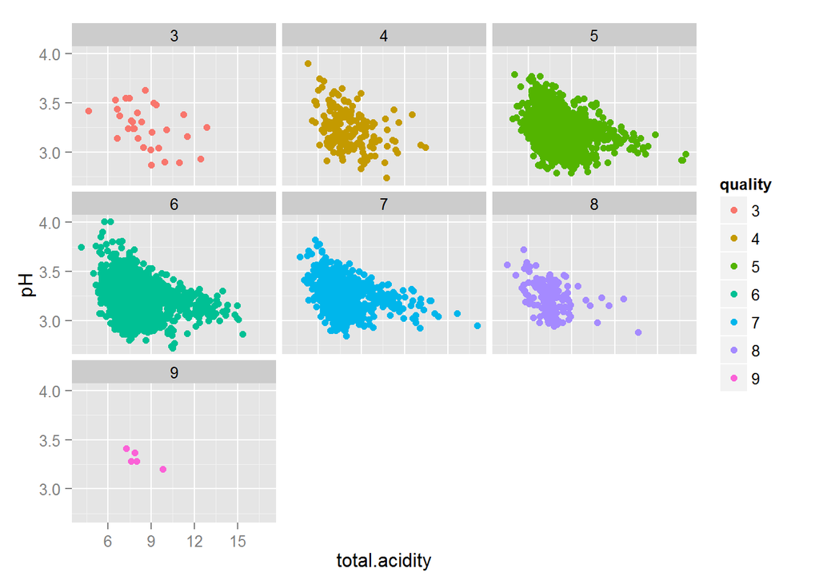

```r
ggplot(wine,aes(x=total.acidity, y=pH,color=quality))+
  geom_point()+facet_wrap(~quality)
```

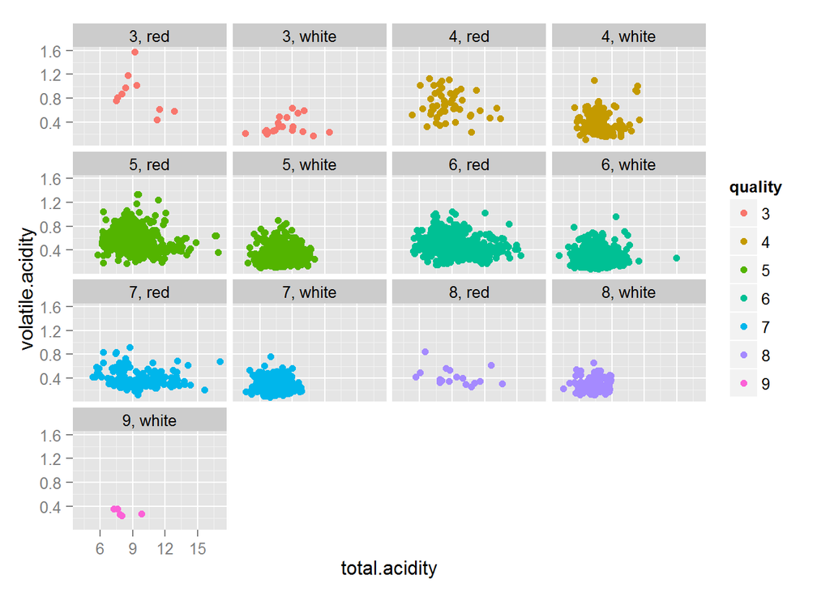

```r
ggplot(wine,aes(x=total.acidity, y=volatile.acidity,color=quality))+
  geom_point()+facet_wrap(~quality+type)
```

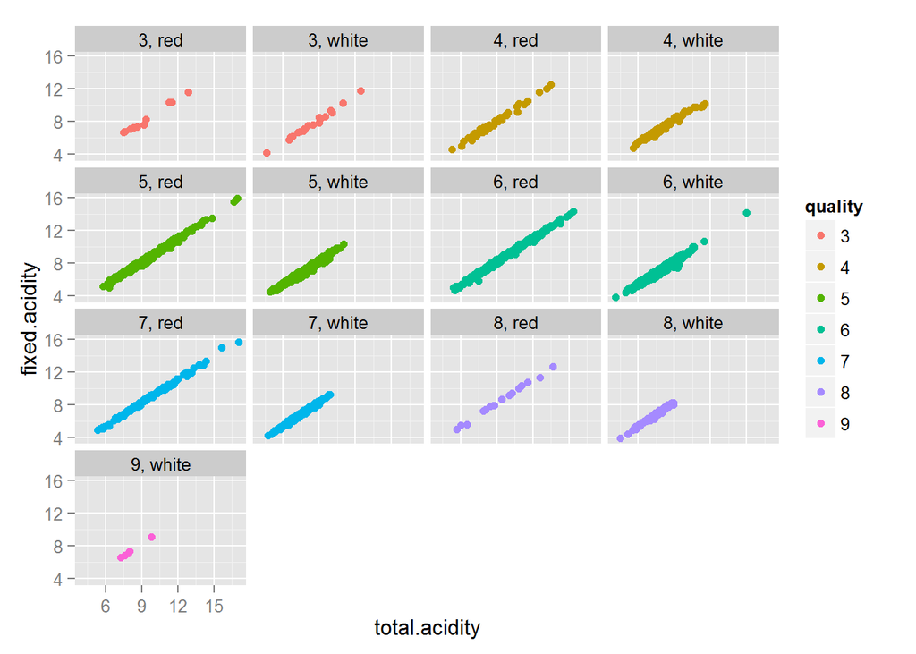

```r
ggplot(wine,aes(x=total.acidity, y=fixed.acidity,color=quality))+
  geom_point()+facet_wrap(~quality+type)
```

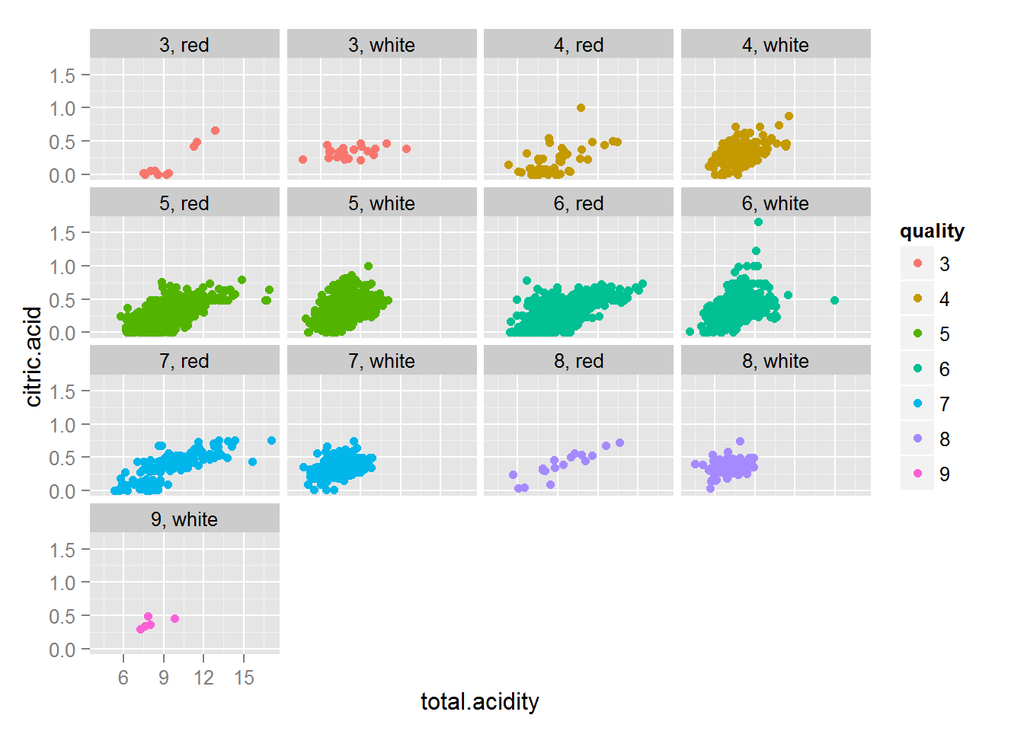

```r
ggplot(wine,aes(x=total.acidity, y=citric.acid,color=quality))+
  geom_point()+facet_wrap(~quality+type)
```

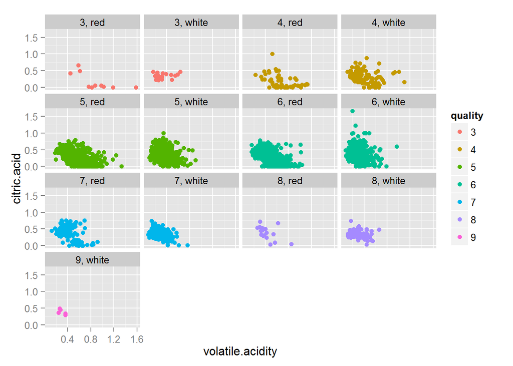

```r
ggplot(wine,aes(x=volatile.acidity, y=citric.acid,color=quality))+
  geom_point()+facet_wrap(~quality+type)
```

```r
summary(wine$total.acidity)
```

```
##    Min. 1st Qu.  Median    Mean 3rd Qu.    Max.
##   4.130   7.020   7.600   7.874   8.380  17.040
```

```r
summary(wine$volatile.acidity)
```

```
##    Min. 1st Qu.  Median    Mean 3rd Qu.    Max.
##  0.0800  0.2300  0.2900  0.3397  0.4000  1.5800
```

```r
summary(wine$fixed.acidity)
```

```
##    Min. 1st Qu.  Median    Mean 3rd Qu.    Max.
##   3.800   6.400   7.000   7.215   7.700  15.900
```

```r
summary(wine$citric.acid)
```

```
##    Min. 1st Qu.  Median    Mean 3rd Qu.    Max.
##  0.0000  0.2500  0.3100  0.3186  0.3900  1.6600
```

The total wine acidity is dominated by fixed acidity. There does not seem to be any strong direct associated with any one acid. It is hard to tell because of the lower sample sizes, but it looks that higher quality wines seem to shrink down to an ellipse in the citric acid/volatile acidity space.

### Residual Surgar

Residual sugar is associated with the sweetness of the wine. White wines tend to have higher amounts of residual sugar compared to red wines.

```r
summary(wine$residual.sugar)
```

```
##    Min. 1st Qu.  Median    Mean 3rd Qu.    Max.
##   0.600   1.800   3.000   5.443   8.100  65.800
```

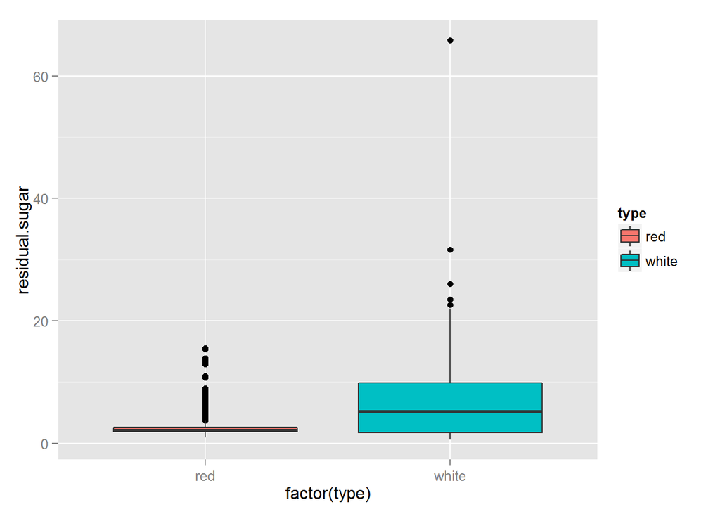

```r
ggplot(wine,aes(factor(type),residual.sugar,fill=type))+geom_boxplot()
```

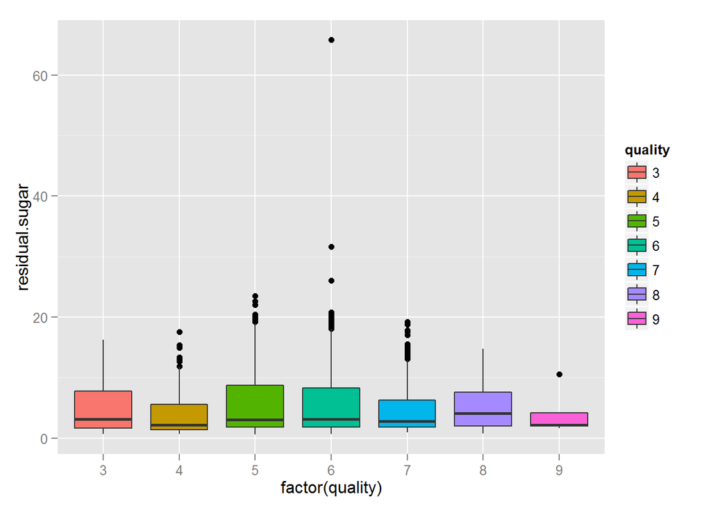

```r
ggplot(wine,aes(factor(quality),residual.sugar,fill=quality))+geom_boxplot()
```

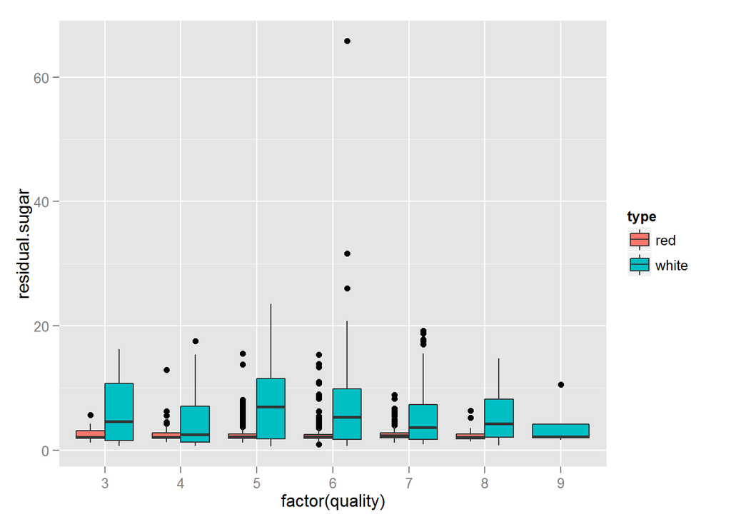

```r
ggplot(wine,aes(factor(quality),residual.sugar,fill=type))+geom_boxplot()
```

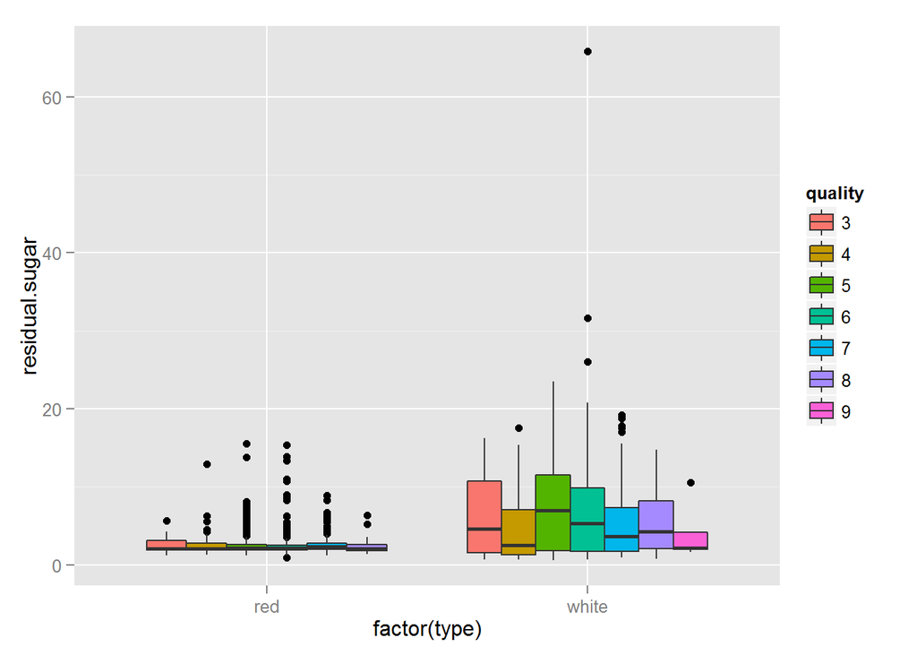

```r
ggplot(wine,aes(factor(type),residual.sugar,fill=quality))+geom_boxplot()
```

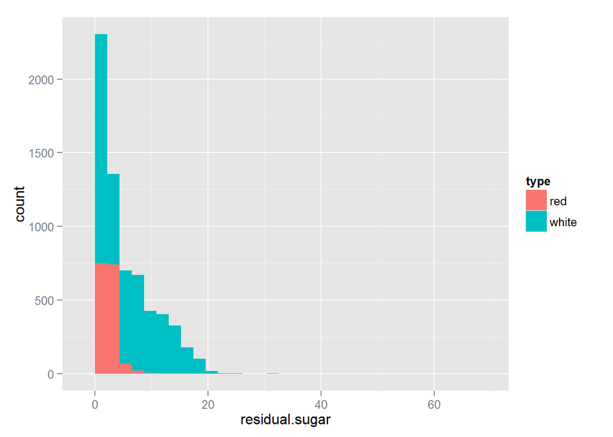

```r
ggplot(wine,aes(residual.sugar,fill=type))+geom_histogram()
```

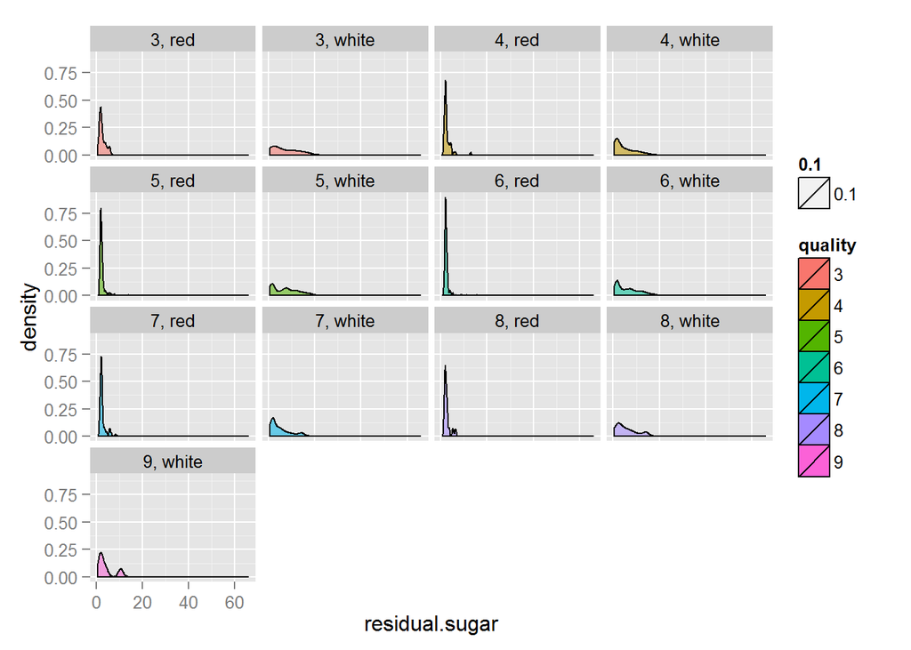

```r
ggplot(wine,aes(residual.sugar,fill=quality,alpha=0.1))+
  geom_density()+facet_wrap(~quality+type)
```

### Chlorides

This is a measure of sodium chlorides (salt) found in the wine. The effect of salt is disputed on wines, but ‘moderate’ amounts tend to ‘smooth-out’ the wine.

```r
summary(wine$chlorides)
```

```
##    Min. 1st Qu.  Median    Mean 3rd Qu.    Max.
## 0.00900 0.03800 0.04700 0.05603 0.06500 0.61100
```

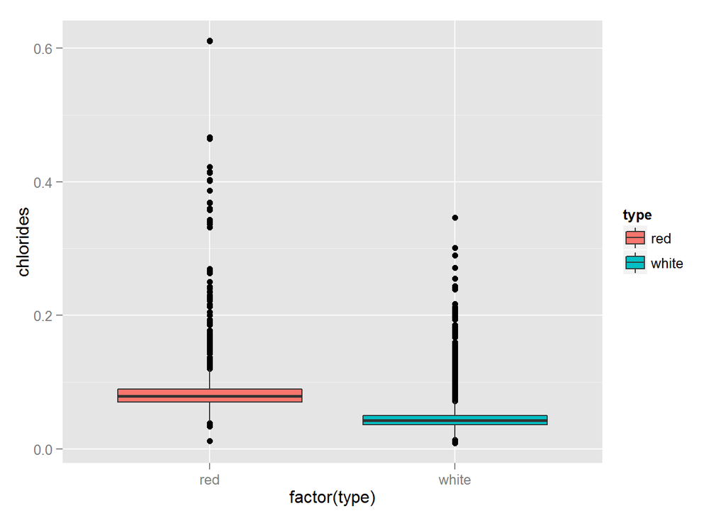

```r
ggplot(wine,aes(factor(type),chlorides,fill=type))+geom_boxplot()
```

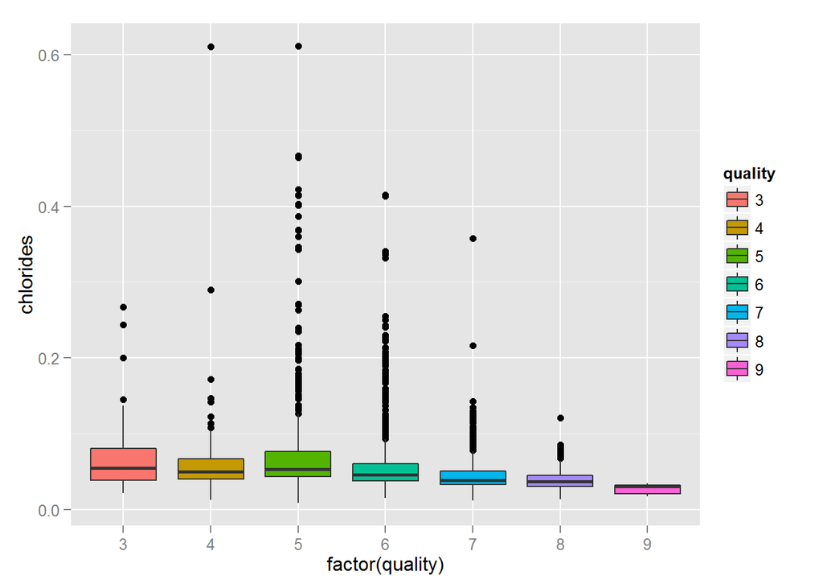

```r
ggplot(wine,aes(factor(quality),chlorides,fill=quality))+geom_boxplot()
```

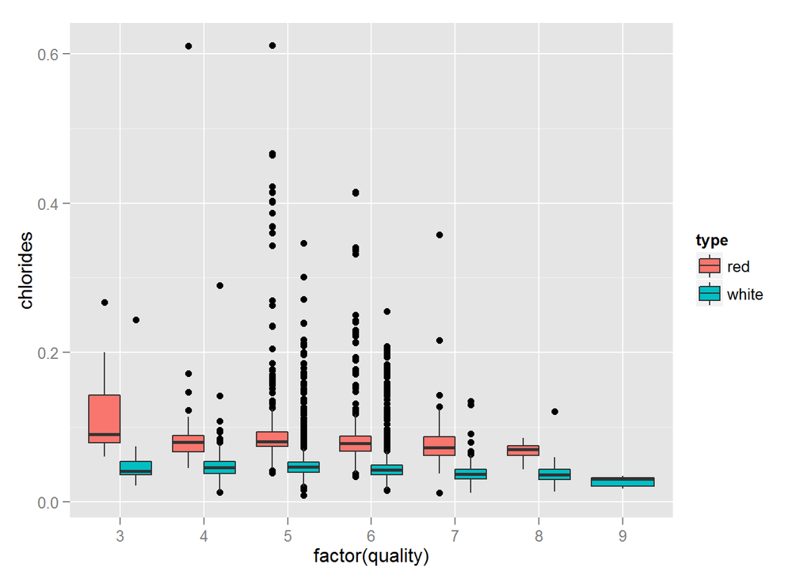

```r
ggplot(wine,aes(factor(quality),chlorides,fill=type))+geom_boxplot()
```

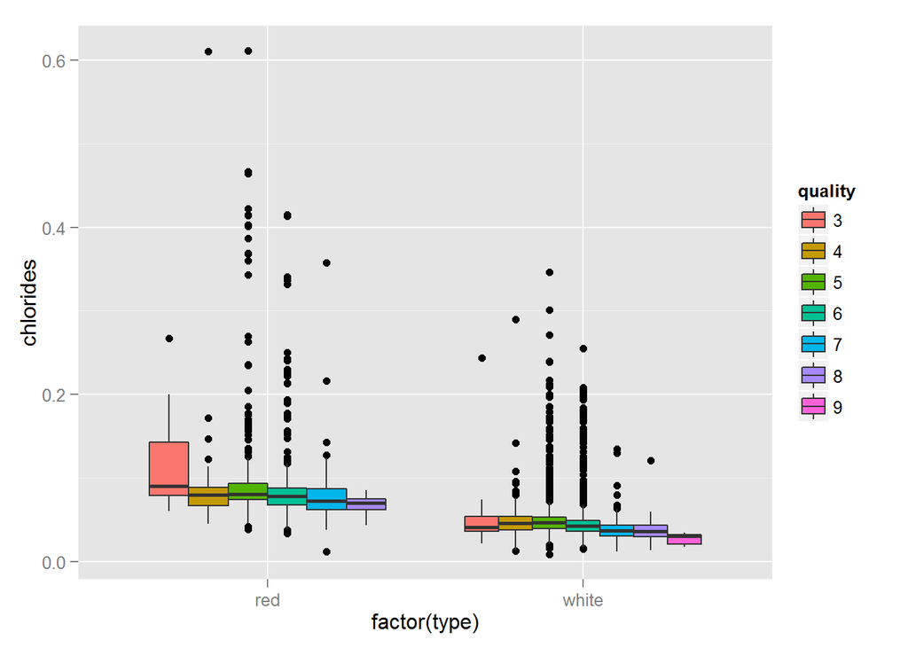

```r
ggplot(wine,aes(factor(type),chlorides,fill=quality))+geom_boxplot()
```

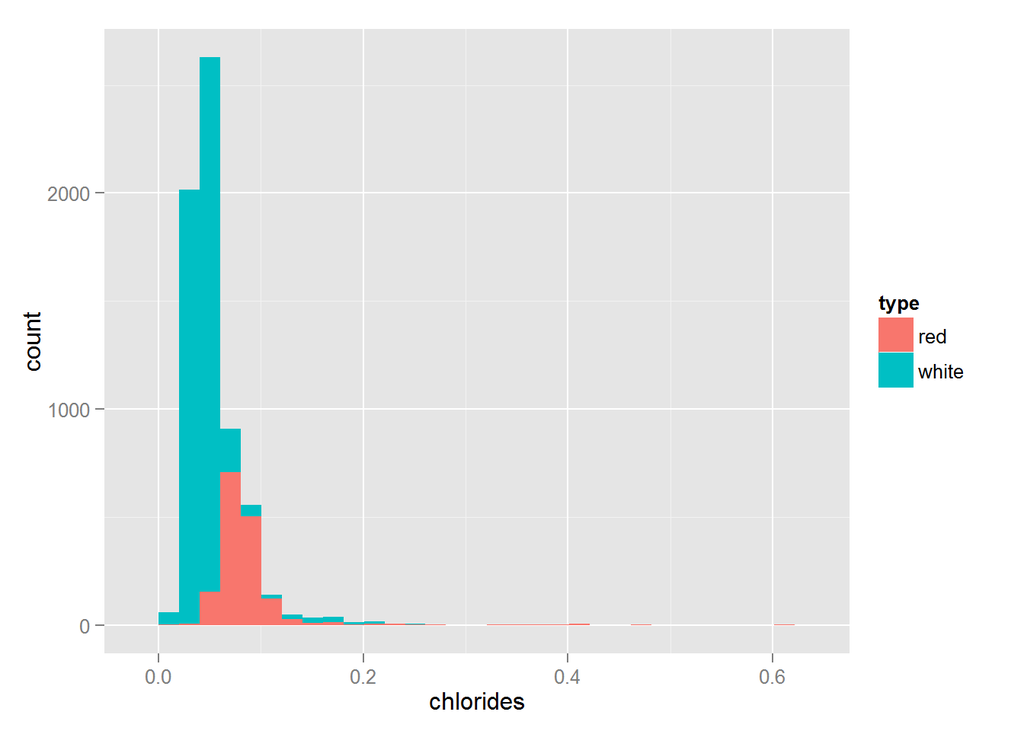

```r
ggplot(wine,aes(chlorides,fill=type))+geom_histogram()
```

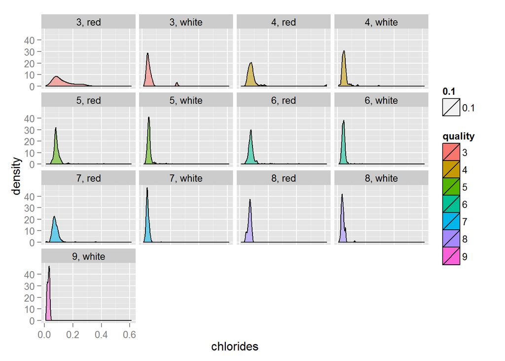

```r
ggplot(wine,aes(chlorides,fill=quality,alpha=0.1))+geom_density()+facet_wrap(~quality+type)
```

Whites have lower chlorides levels then reds, and the higher quality reds have distributions that are lower than those lower quality reds.

### Free Sulfer Dioxide

Sulfur dioxide can bind with odor producing chemicals and be an antibiotic agent. It also reacts with a number of other chemicals found in wines, so it is used gingerly.

```r
summary(wine$free.sulfur.dioxide)
```

```
##    Min. 1st Qu.  Median    Mean 3rd Qu.    Max.
## 0.00100 0.01700 0.02900 0.03053 0.04100 0.28900
```

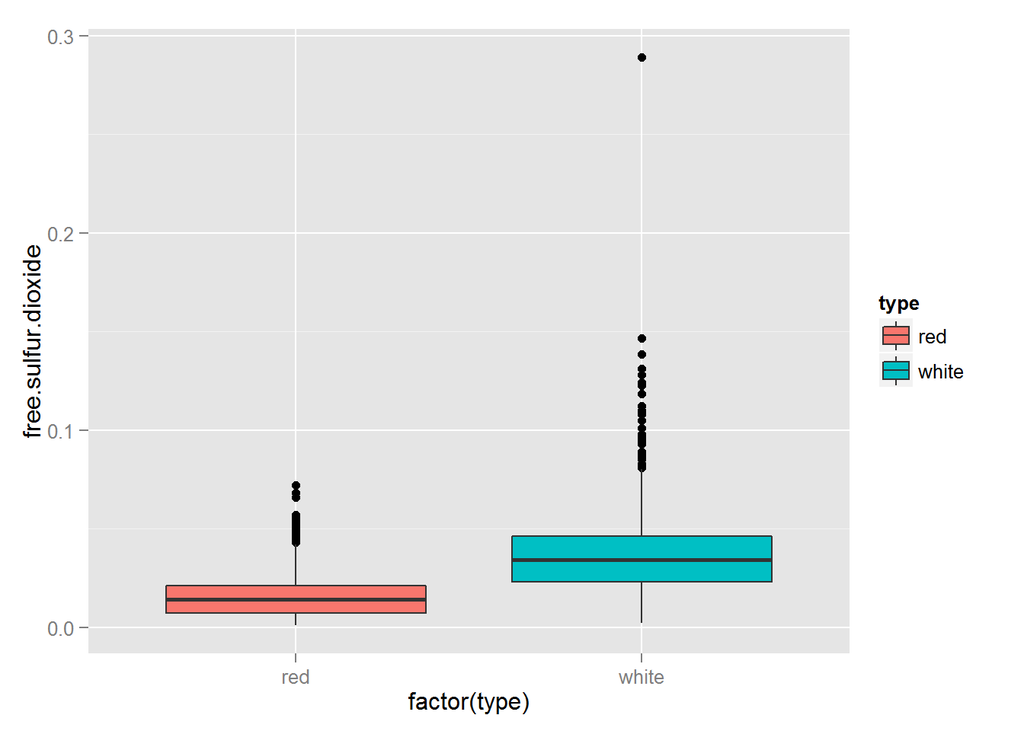

```r
ggplot(wine,aes(factor(type),free.sulfur.dioxide,fill=type))+geom_boxplot()
```

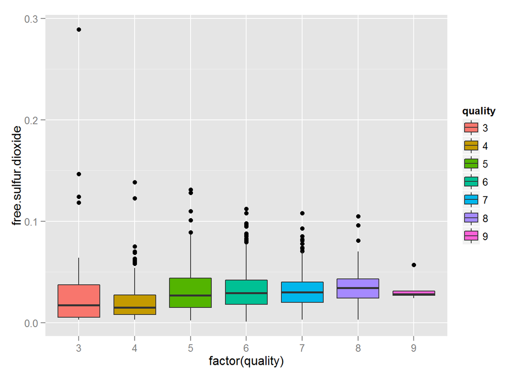

```r
ggplot(wine,aes(factor(quality),free.sulfur.dioxide,fill=quality))+geom_boxplot()
```

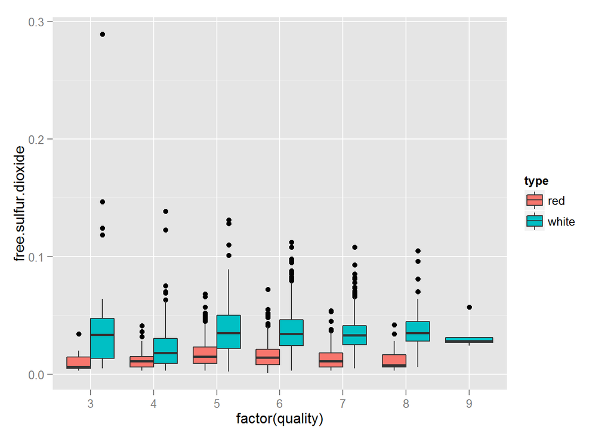

```r
ggplot(wine,aes(factor(quality),free.sulfur.dioxide,fill=type))+geom_boxplot()
```

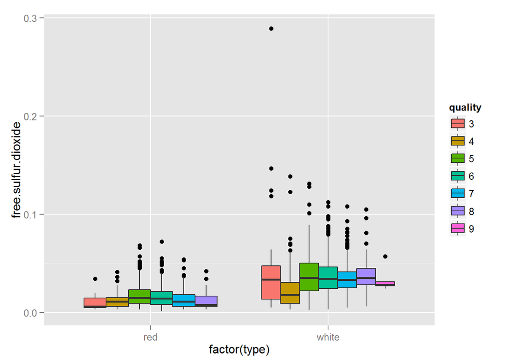

```r
ggplot(wine,aes(factor(type),free.sulfur.dioxide,fill=quality))+geom_boxplot()
```

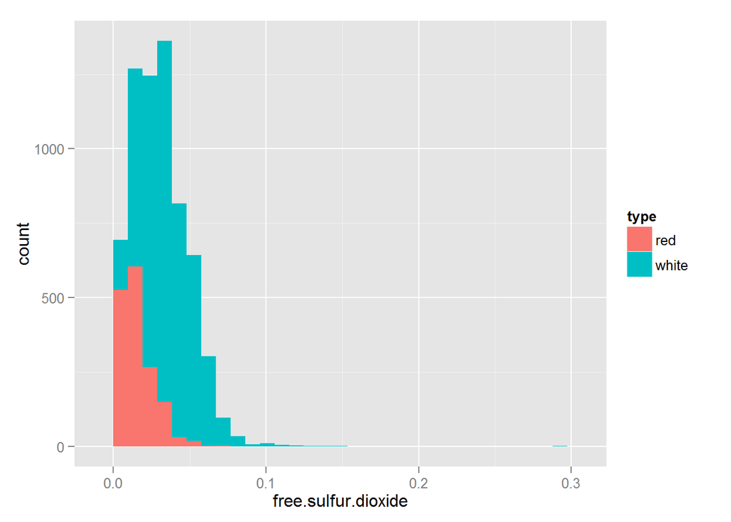

```r
ggplot(wine,aes(free.sulfur.dioxide,fill=type))+geom_histogram()
```

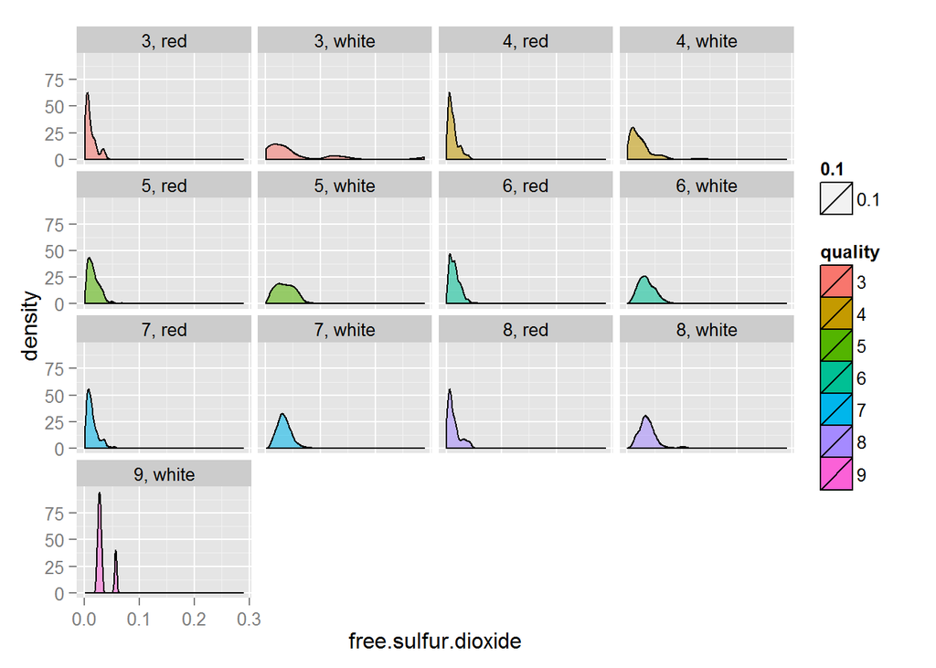

```r
ggplot(wine,aes(free.sulfur.dioxide,fill=quality,alpha=0.1))+geom_density()+facet_wrap(~quality+type)
```

Red wines have lower amounts of S02 compared to white wines, and there seems to a small association between poor white wines and lower free sulfur dioxide levels.

### Total Sulur Dioxide

```r
summary(wine$total.sulfur.dioxide)
```

```
##    Min. 1st Qu.  Median    Mean 3rd Qu.    Max.
##  0.0060  0.0770  0.1180  0.1157  0.1560  0.4400
```

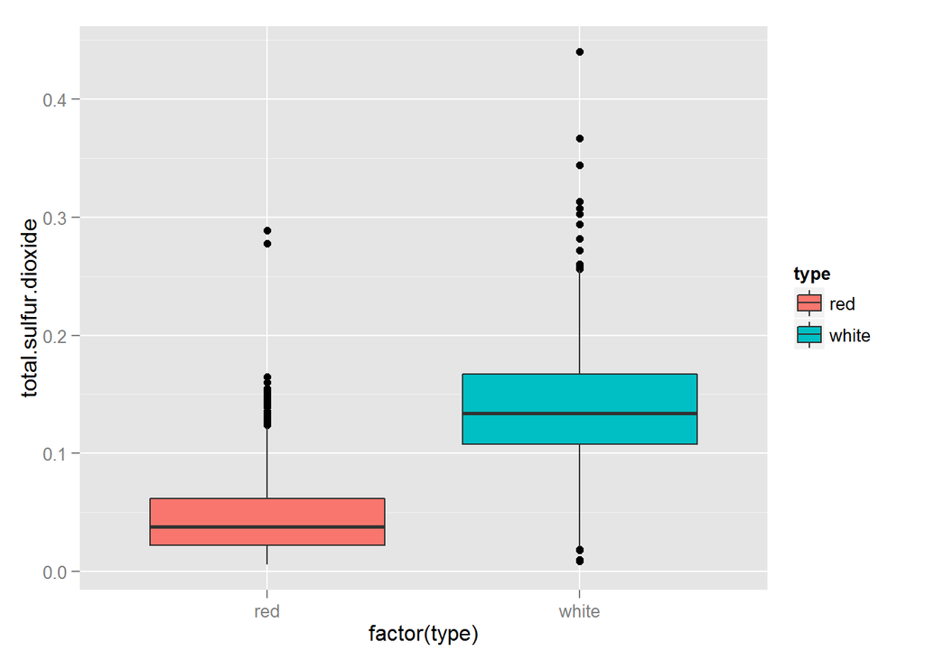

```r
ggplot(wine,aes(factor(type),total.sulfur.dioxide,fill=type))+geom_boxplot()
```

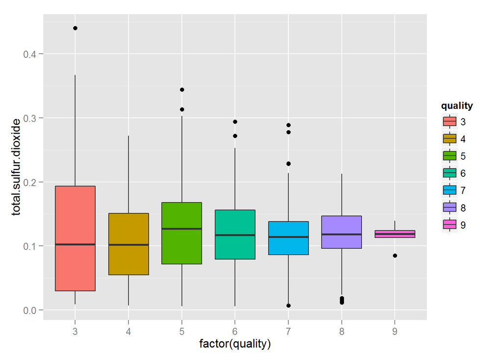

```r
ggplot(wine,aes(factor(quality),total.sulfur.dioxide,fill=quality))+geom_boxplot()
```

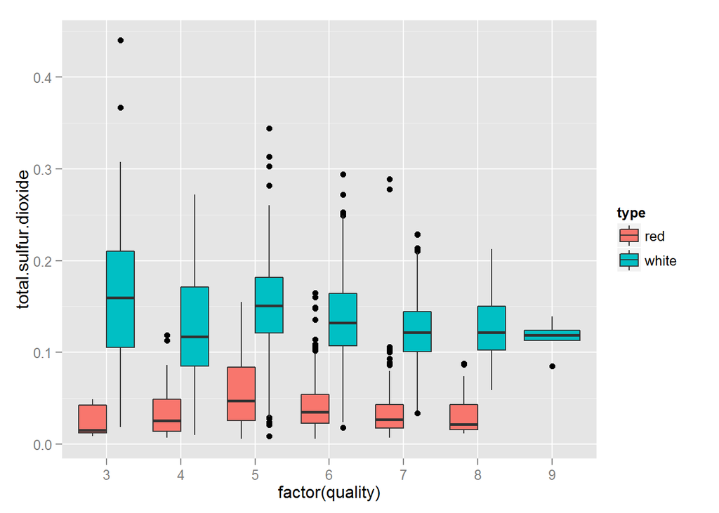

```r
ggplot(wine,aes(factor(quality),total.sulfur.dioxide,fill=type))+geom_boxplot()
```

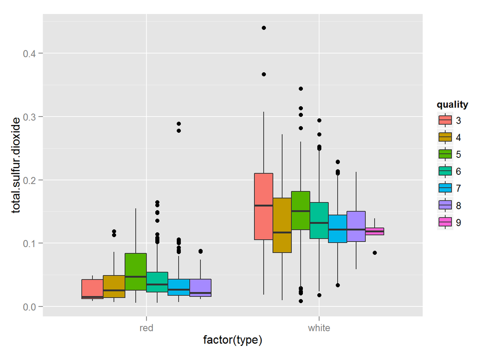

```r
ggplot(wine,aes(factor(type),total.sulfur.dioxide,fill=quality))+geom_boxplot()
```

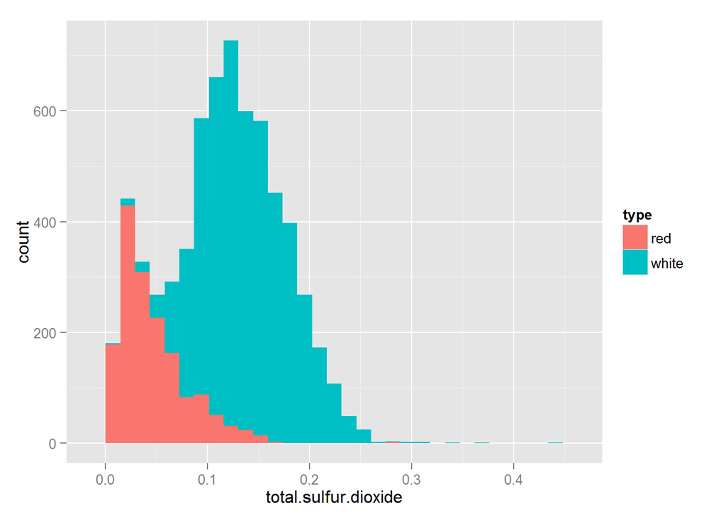

```r
ggplot(wine,aes(total.sulfur.dioxide,fill=type))+geom_histogram()
```

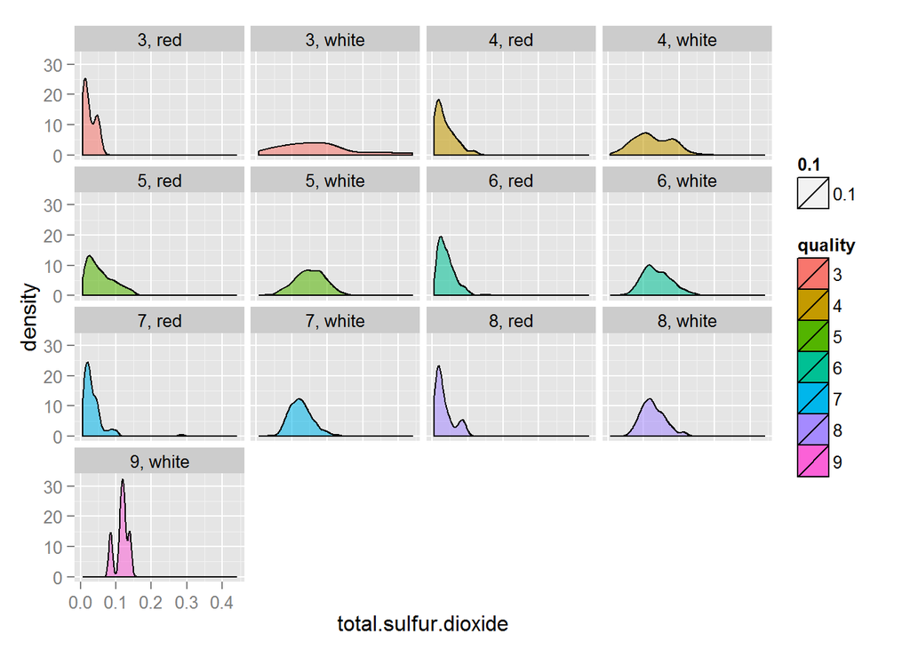

```r
ggplot(wine,aes(total.sulfur.dioxide,fill=quality,alpha=0.1))+
  geom_density()+facet_wrap(~quality+type)
```

Total sulfur dioxide levels seem consistent across quality, but white wines have higher values over red wines.

### Sulphites (Sulphates are not in wine)

The data set states sulfates but sulfides are added to wine to limit microbial growth.

```r
summary(wine$sulphates)
```

```
##    Min. 1st Qu.  Median    Mean 3rd Qu.    Max.
##  0.2200  0.4300  0.5100  0.5313  0.6000  2.0000
```

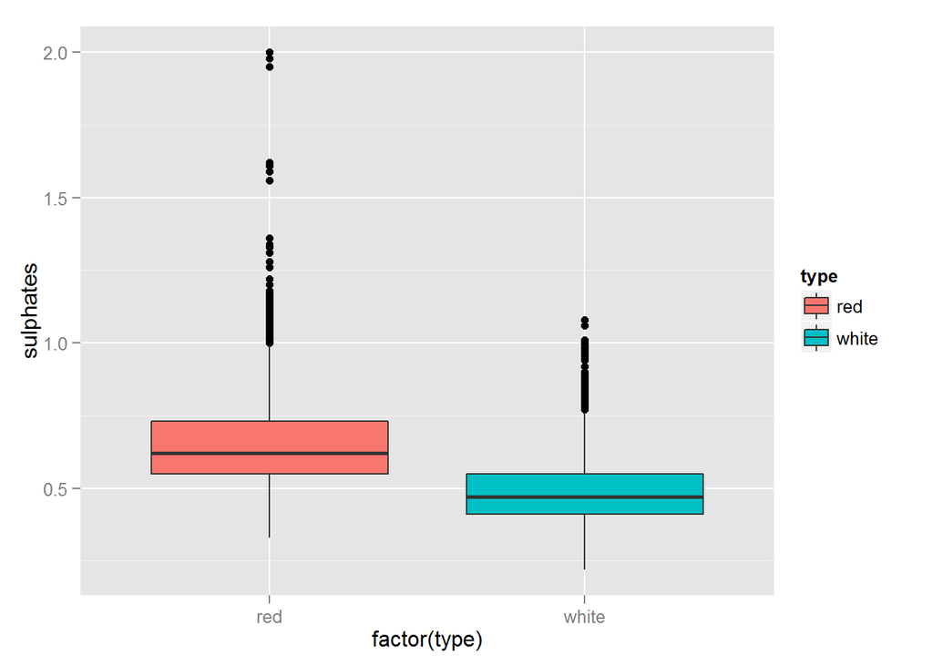

```r
ggplot(wine,aes(factor(type),sulphates,fill=type))+geom_boxplot()
```

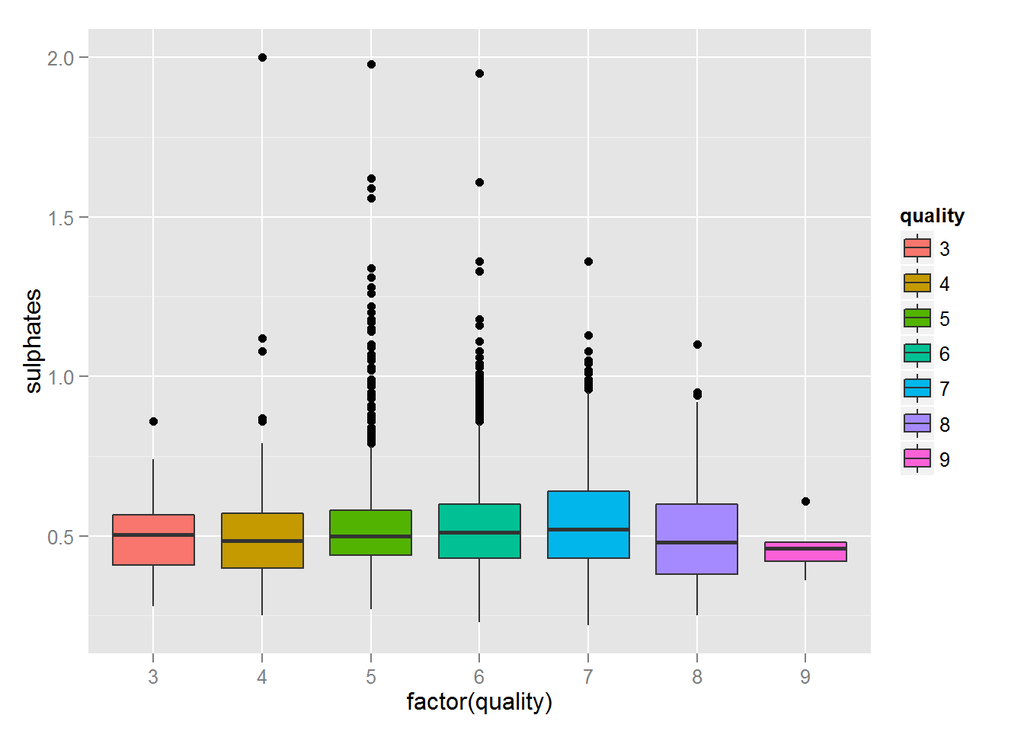

```r
ggplot(wine,aes(factor(quality),sulphates,fill=quality))+geom_boxplot()
```

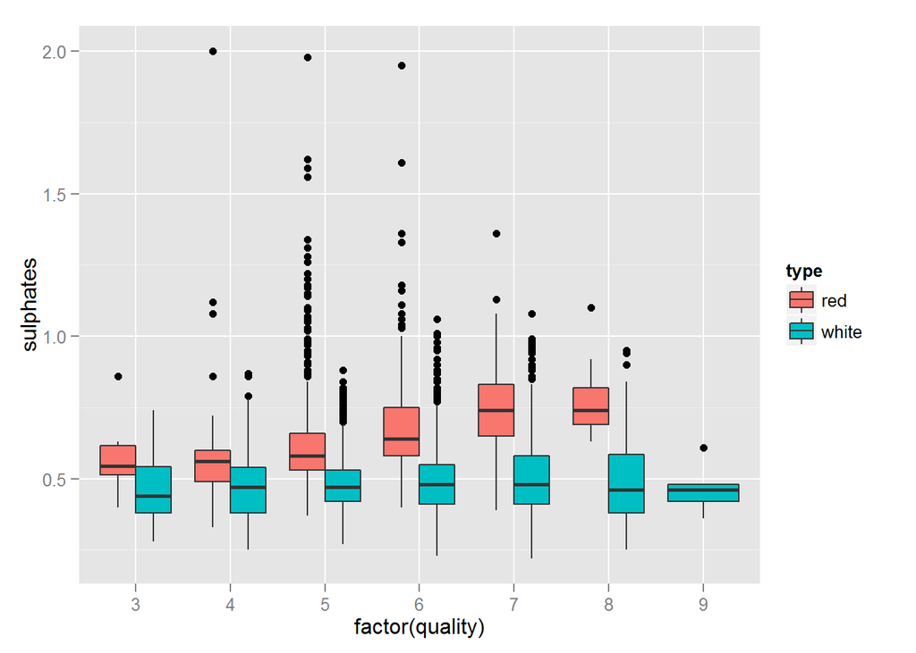

```r
ggplot(wine,aes(factor(quality),sulphates,fill=type))+geom_boxplot()
```

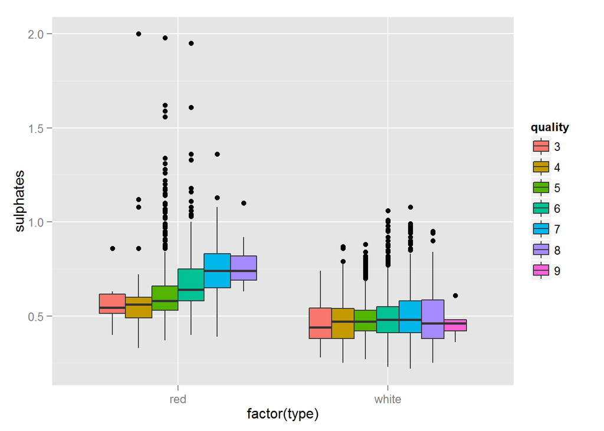

```r
ggplot(wine,aes(factor(type),sulphates,fill=quality))+geom_boxplot()
```

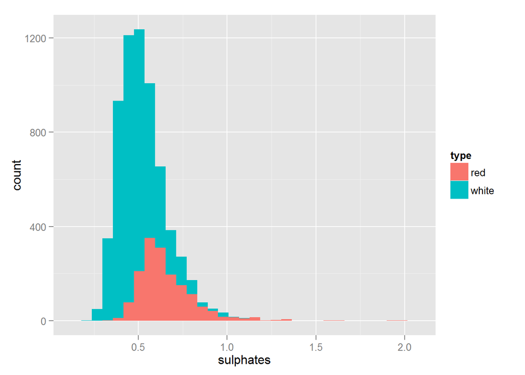

```r
ggplot(wine,aes(sulphates,fill=type))+geom_histogram()
```

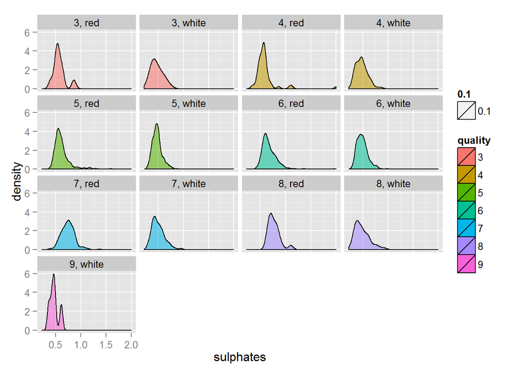

```r
ggplot(wine,aes(sulphates,fill=quality,alpha=0.1))+
  geom_density()+facet_wrap(~quality+type)
```

White wines have lower amounts of sulfates, and higher quality red wines seem to have more sulfates.

### Alcohol

Alcohol is why we drink wine.

```r
summary(wine$alcohol)
```

```
##    Min. 1st Qu.  Median    Mean 3rd Qu.    Max.
##    8.00    9.50   10.30   10.49   11.30   14.90
```

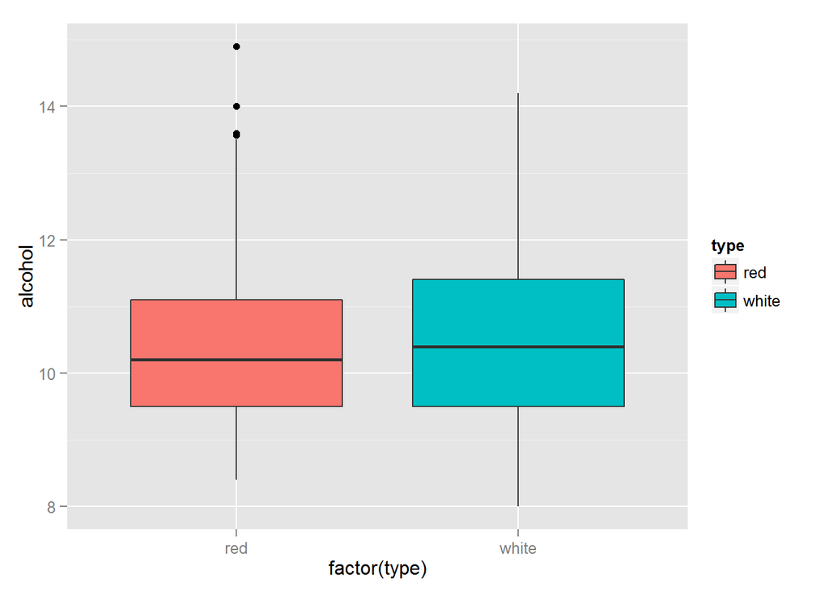

```r
ggplot(wine,aes(factor(type),alcohol,fill=type))+geom_boxplot()
```

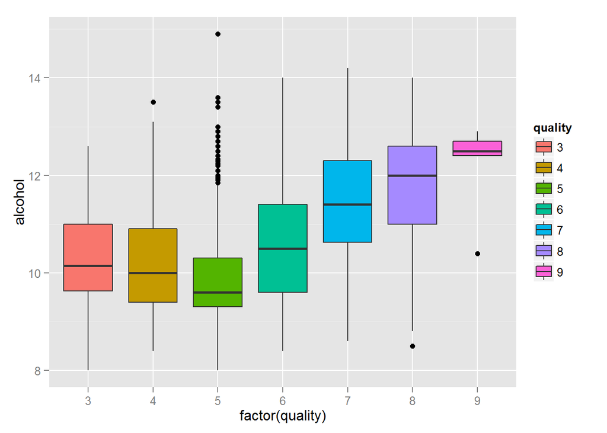

```r
ggplot(wine,aes(factor(quality),alcohol,fill=quality))+geom_boxplot()
```

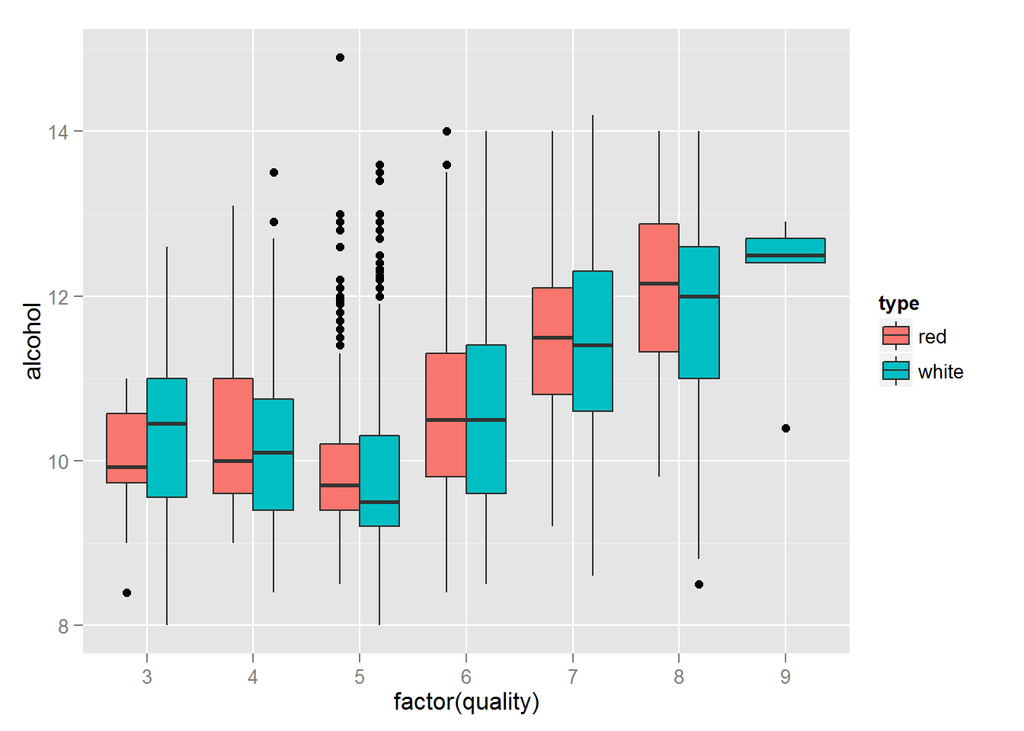

```r
ggplot(wine,aes(factor(quality),alcohol,fill=type))+geom_boxplot()
```

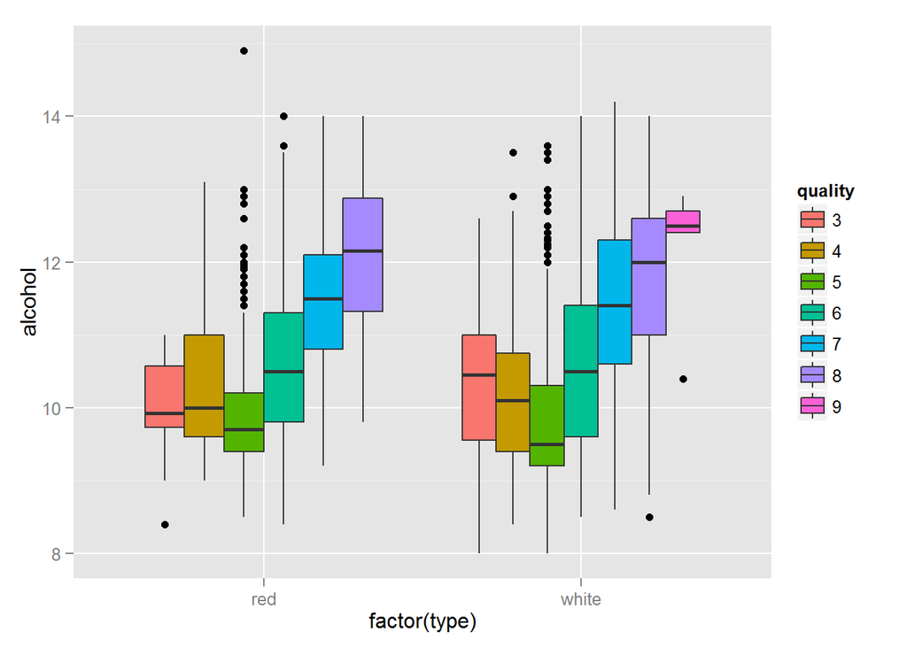

```r
ggplot(wine,aes(factor(type),alcohol,fill=quality))+geom_boxplot()
```

This amuses me to no end! This is the only metric that agrees with quality across both types of wine. Red and white wines of higher quality have more alcohol!

Since alcohol is low density it is interesting to me to see if there is a relationships between density and % alcohol.

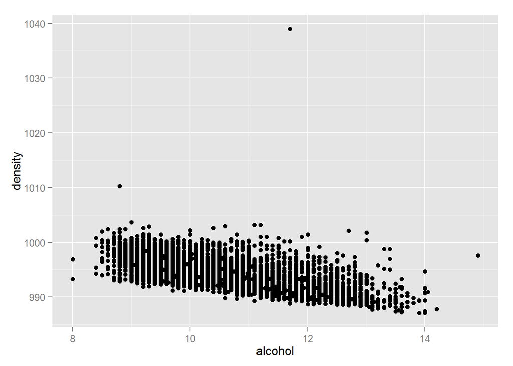

```r
ggplot(wine,aes(x=alcohol,y=density))+geom_point()
```

A quick Google search pulls up this equation for the density of wine:

789*%-alcohol + 1587*%-residual.sugar + (1-%-alcohol-%-residual.surfer)*1000 = density.

Lets check it

```r
wine$density.predicted = 789*wine$alcohol
wine$density.predicted = wine$density.predicted +
  1587*wine$residual.sugar/10
wine$density.predicted = wine$density.predicted +
  (100-wine$alcohol-wine$residual.sugar/10)*1000
wine$density.predicted = wine$density.predicted/100
summary(wine$density.predicted)
```

```
##    Min. 1st Qu.  Median    Mean 3rd Qu.    Max.
##   971.0   977.9   980.5   981.1   983.6  1014.0
```

```r
summary(wine$density)
```

```
##    Min. 1st Qu.  Median    Mean 3rd Qu.    Max.
##   987.1   992.3   994.9   994.7   997.0  1039.0
```

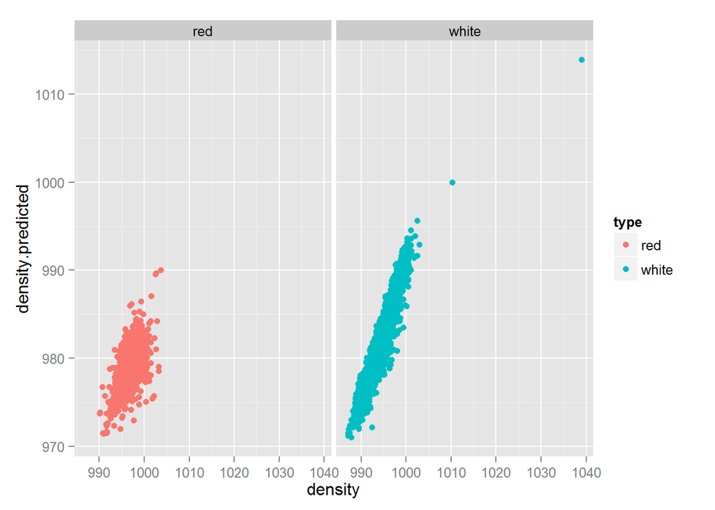

```r
ggplot(wine,aes(x=density,y=density.predicted,color=type))+
  geom_point()+facet_wrap(~type)
```

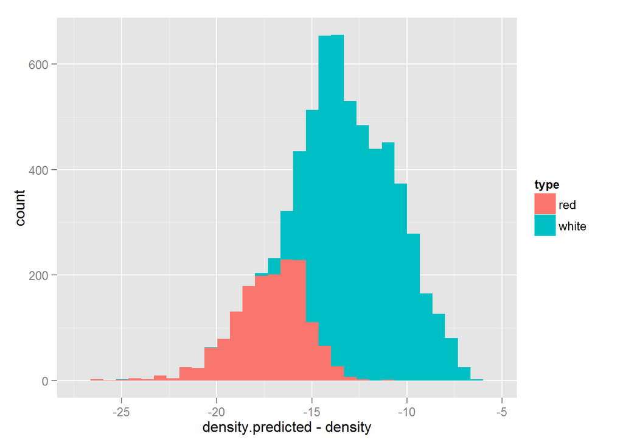

```r
ggplot(wine,aes(density.predicted-density,fill=type))+geom_histogram()
```

The actual densities are larger than the predicted density for the wines. The difference is larger for red wines. There also seems to be more scatter in red wines, but the white wines seem to be fairly linear.

I am if other quantities are associated with this difference.

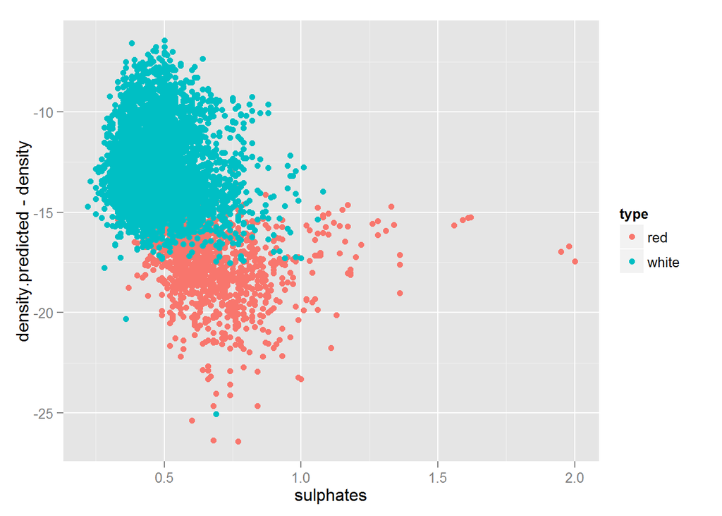

```r
ggplot(wine,aes(x=sulphates,y=density.predicted-density,color=type))+
  geom_point()
```

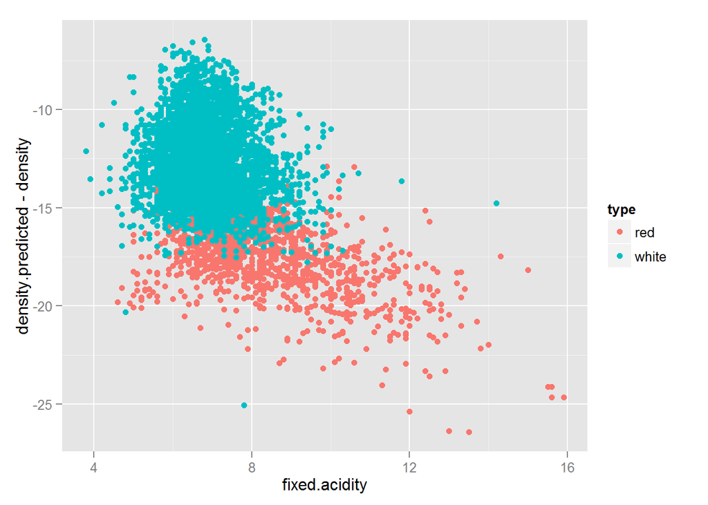

```r
ggplot(wine,aes(x=fixed.acidity,y=density.predicted-density,color=type))+
  geom_point()
```

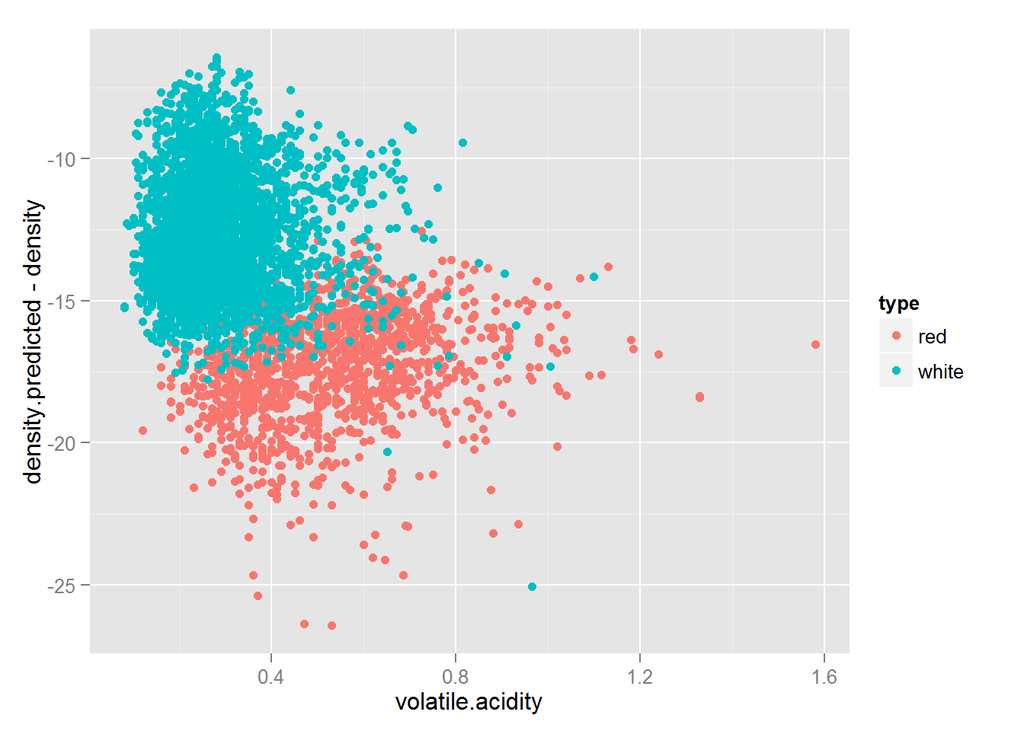

```r
ggplot(wine,aes(x=volatile.acidity,y=density.predicted-density,color=type))+
  geom_point()
```

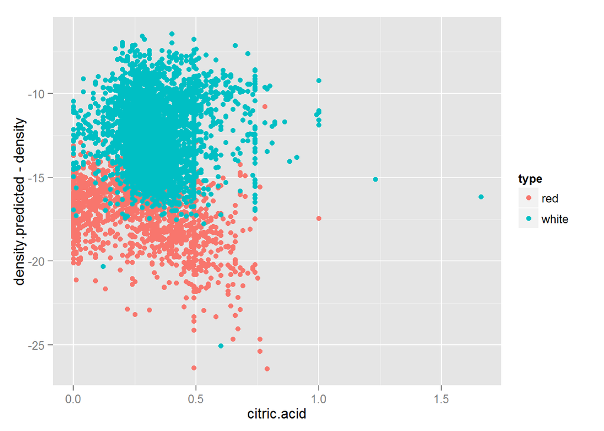

```r
ggplot(wine,aes(x=citric.acid,y=density.predicted-density,color=type))+
  geom_point()
```

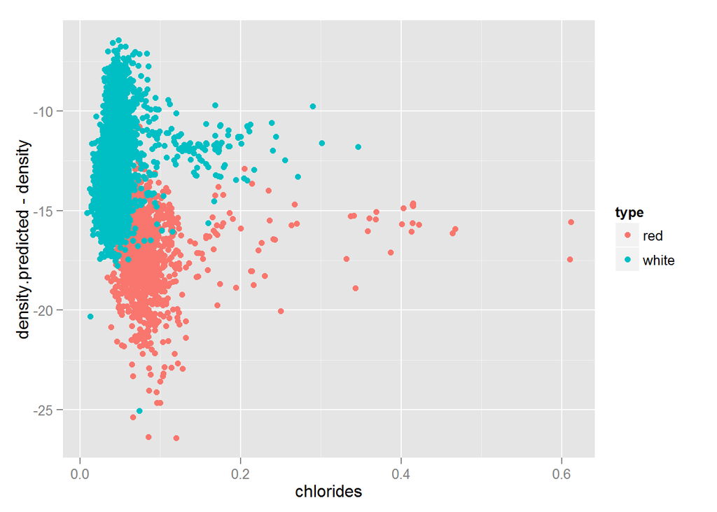

```r
ggplot(wine,aes(x=chlorides,y=density.predicted-density,color=type))+
  geom_point()
```

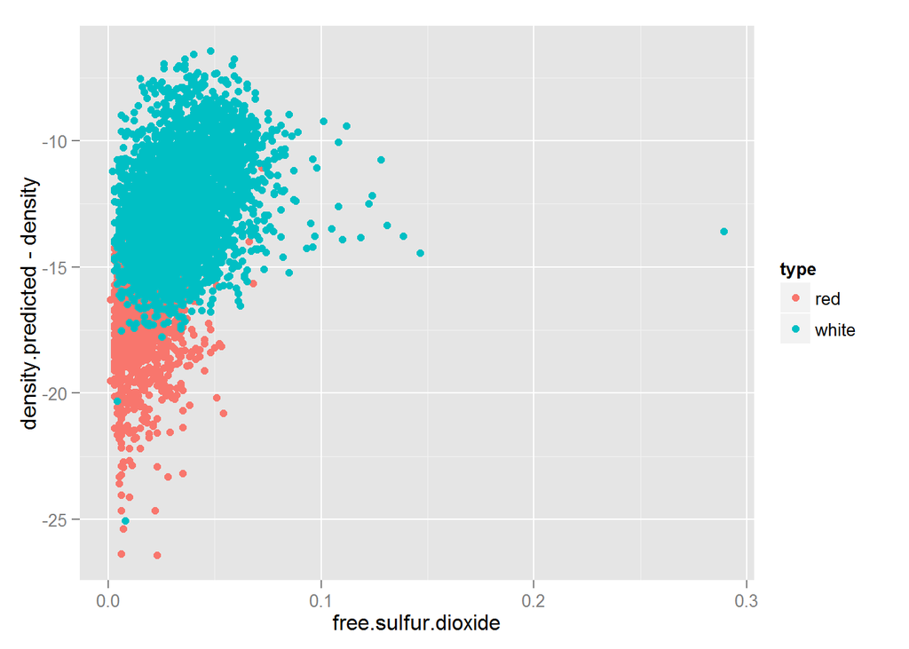

```r
ggplot(wine,aes(x=free.sulfur.dioxide,y=density.predicted-density,color=type))+
  geom_point()
```

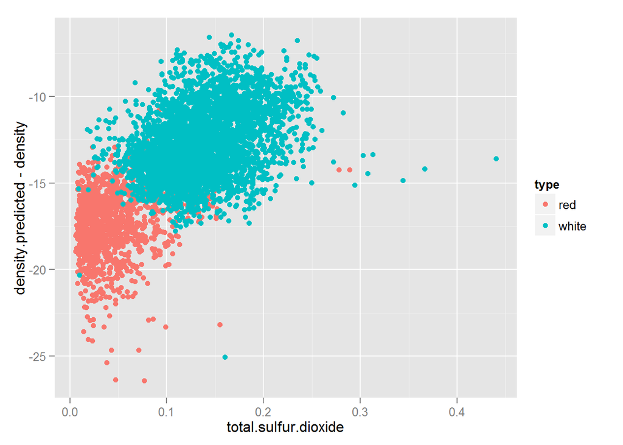

```r
ggplot(wine,aes(x=total.sulfur.dioxide,y=density.predicted-density,color=type))+
  geom_point()
```